# Preliminary Assessment of Strom Event Impacts

## 1.Synopsis

This report documents a quick analysis on the NOAA Storm Data by assessing the harmfulness of population health and economic loss. During the assessment, the NOAA dataset was subseted and cleaned for data processing. Harm_INDEX and DMG_INDEX were created for the assessment. The result indicated that Tornado events caused the most population health impact and the flood events caused the most economic losses.

## 2.Data Processing

### 2.1 Data Preparation

The NOAA Storm Database was used. The raw data contains 37 variables including STATE, EVTYPE, FATALITIES, et cetera. However, only a few were adpted for this analysis, therefore a subset was made.

```r
Sys.setlocale("LC_ALL", "C")
```

```
## [1] "C"
```

```r
stormdata <- read.csv(bzfile("repdata-data-StormData.csv.bz2"), sep=",", stringsAsFactors=FALSE)
str(stormdata)
```

```
## 'data.frame':    902297 obs. of  37 variables:
##  $ STATE__   : num  1 1 1 1 1 1 1 1 1 1 ...
##  $ BGN_DATE  : chr  "4/18/1950 0:00:00" "4/18/1950 0:00:00" "2/20/1951 0:00:00" "6/8/1951 0:00:00" ...
##  $ BGN_TIME  : chr  "0130" "0145" "1600" "0900" ...
##  $ TIME_ZONE : chr  "CST" "CST" "CST" "CST" ...
##  $ COUNTY    : num  97 3 57 89 43 77 9 123 125 57 ...
##  $ COUNTYNAME: chr  "MOBILE" "BALDWIN" "FAYETTE" "MADISON" ...
##  $ STATE     : chr  "AL" "AL" "AL" "AL" ...
##  $ EVTYPE    : chr  "TORNADO" "TORNADO" "TORNADO" "TORNADO" ...
##  $ BGN_RANGE : num  0 0 0 0 0 0 0 0 0 0 ...
##  $ BGN_AZI   : chr  "" "" "" "" ...
##  $ BGN_LOCATI: chr  "" "" "" "" ...
##  $ END_DATE  : chr  "" "" "" "" ...
##  $ END_TIME  : chr  "" "" "" "" ...
##  $ COUNTY_END: num  0 0 0 0 0 0 0 0 0 0 ...
```

[output cut: 23 more lines]

```r
stormdata <- stormdata[,c("EVTYPE","FATALITIES","INJURIES","PROPDMG","PROPDMGEXP","CROPDMG","CROPDMGEXP","REFNUM")]
```

### 2.2 Data Cleaning

It is noteworthy that the “EVTYPE” column which is indicating the type of events contains a lot of redundancy. For example, there were 44 unique EVTYPE values include string “HAIL”, but most of them were refer to the very same event- HAIL. Therefore the EVTYPE must be cleaned to perform a better analysis.

```r
unique(stormdata$EVTYPE[grepl("HAIL", stormdata$EVTYPE)])
```

```
##  [1] "HAIL"                       "THUNDERSTORM WINDS/HAIL"
##  [3] "THUNDERSTORM WINDS HAIL"    "HAIL 1.75)"
##  [5] "HAIL STORM"                 "HAIL 75"
##  [7] "TORNADOES, TSTM WIND, HAIL" "SMALL HAIL"
##  [9] "HAIL 80"                    "FUNNEL CLOUD/HAIL"
## [11] "HAIL 0.75"                  "HAIL 1.00"
## [13] "HAIL/WINDS"                 "HAIL/WIND"
## [15] "HAIL 1.75"                  "WIND/HAIL"
## [17] "THUNDERSTORM WINDS/ HAIL"   "HAIL 225"
## [19] "HAIL 0.88"                  "DEEP HAIL"
## [21] "HAIL 88"                    "HAIL 175"
## [23] "HAIL 100"                   "HAIL 150"
## [25] "HAIL 075"                   "HAIL 125"
## [27] "HAIL 200"                   "HAIL FLOODING"
## [29] "HAIL DAMAGE"                "THUNDERSTORM HAIL"
## [31] "HAIL 088"                   "THUNDERSTORM WINDSHAIL"
## [33] "HAIL/ICY ROADS"             "HAIL ALOFT"
## [35] "THUNDERSTORM WIND/HAIL"     "HAIL 275"
## [37] "HAIL 450"                   "HAILSTORM"
## [39] "HAILSTORMS"                 "TSTM WIND/HAIL"
## [41] "GUSTY WIND/HAIL"            "LATE SEASON HAIL"
## [43] "NON SEVERE HAIL"            "MARINE HAIL"
```

```r
stormdata$cate <- toupper(stormdata$EVTYPE)

stormdata$cate[grepl("^( *)", stormdata$cate)] <- (gsub("^( *)", "", stormdata$cate[grepl("^( *)", stormdata$cate)]))
stormdata$cate[grepl(" +", stormdata$cate)] <- (gsub(" +", " ", stormdata$cate[grepl(" +", stormdata$cate)]))
stormdata$cate[grepl("S+\\b", stormdata$cate)] <- gsub("S+\\b", "", stormdata$cate[grepl("S+\\b", stormdata$cate)])
stormdata$cate[grepl(" AND$", stormdata$cate)] <- (gsub(" AND$", "", stormdata$cate[grepl(" AND$", stormdata$cate)]))

stormdata$cate[grepl("^(SUMMARY|Summary)", stormdata$cate)] <- "SUMMARY"

stormdata$cate[grepl("(SMALL|DEEP|NON SEVERE|LATE SEASON) HAIL", stormdata$cate)] <- "HAIL"
stormdata$cate[grepl("HAIL (DAMAGE|ALOFT|[0-9])", stormdata$cate)] <- "HAIL"

stormdata$cate[grepl("^TORNADO(E)?( DEBRI)?( F[0-9])?$", stormdata$cate)] <- "TORNADO"

stormdata$cate[grepl("TSTM", stormdata$cate)] <- (gsub("TSTM", "THUNDERSTORM", stormdata$cate[grepl("TSTM", stormdata$cate)]))
stormdata$cate[grepl("^THUNDERSTORM(W)? (WIND)?(S)? ?\\(?G?[0-9]", stormdata$cate)] <- "THUNDERSTORM WIND"
stormdata$cate[grepl("^(SEVERE |GUSTY )?THUNDERSTORM(W)? ?(W)? ?(I)?(N)?(D)? ?(.)?(G)?( DAMAGE| TO| LE CEN)?$", stormdata$cate)] <- "THUNDERSTORM WIND"
stormdata$cate[grepl("^THUNDERSTORM WIND(/)? ?(TREE)?$", stormdata$cate)] <- "THUNDERSTORM WIND"

stormdata$cate[grepl("^HIGH WIND [0-9]", stormdata$cate)] <- "HIGH WIND"
stormdata$cate[grepl("^HIGH WIND(/)?$", stormdata$cate)] <- "HIGH WIND"
stormdata$cate[grepl("^HIGH WIND \\(.*\\)", stormdata$cate)] <- "HIGH WIND"

stormdata$cate[grepl("FLOODING|FLOODIN", stormdata$cate)] <- (gsub("FLOODING|FLOODIN", "FLOOD", stormdata$cate[grepl("FLOODING|FLOODIN", stormdata$cate)]))
stormdata$cate[grepl("^(RURAL|MINOR|MAJOR|SNOWMELT|HIGHWAY|STREET|RIVER|LOCAL) FLOOD$", stormdata$cate)] <- "FLOOD"
stormdata$cate[grepl("^(URBAN|SMALL STREAM|RIVER)?.?( AND )?(SMALL)? ?(URBAN|STREAM|STREET)? ?FLOOD$", stormdata$cate)] <- "FLOOD"
stormdata$cate[grepl("^FLOOD( WATCH)?/(RIVER FLOOD)?$", stormdata$cate)] <- "FLOOD"

stormdata$cate[grepl("^LAKE FLOOD$", stormdata$cate)] <- "LAKESHORE FLOOD"

stormdata$cate[grepl("^COASTAL( *)FLOOD?$", stormdata$cate)] <- "COASTAL FLOOD"
stormdata$cate[grepl("^BEACH FLOOD?$", stormdata$cate)] <- "COASTAL FLOOD"

stormdata$cate[grepl("^(LOCAL )?FLASH FLOOD(/)( STREET)?$", stormdata$cate)] <- "FLASH FLOOD"
stormdata$cate[grepl("^FLOOD( |/)FLASH$", stormdata$cate)] <- "FLASH FLOOD"
stormdata$cate[grepl("^ICE JAM FLOOD (\\(MINOR)?$", stormdata$cate)] <- "FLASH FLOOD"
stormdata$cate[grepl("^FLASH FLOOD FROM ICE JAM$", stormdata$cate)] <- "FLASH FLOOD"

stormdata$cate[grepl("^LIGHT(N)?(ING)?(\\.)? ?(DAMAGE|INJURY|FIRE)?$", stormdata$cate)] <- "LIGHTNING"

stormdata$cate[grepl("HURRICANE|TYPHOON", stormdata$cate)] <- "HURRICANE(TYPHOON)"

stormdata$cate[grepl("^LANDSLIDE|LANDSLUMP", stormdata$cate)] <- "DEBRIS FLOW"

stormdata$cate[grepl("EXTREME COLD", stormdata$cate)] <- "EXTREME COLD/WIND CHILL"

stormdata$cate[grepl("^(PATCHY )?(DENSE )?FOG$", stormdata$cate)] <- "DENSE FOG"

stormdata$cate[grepl("^ICE FOG$", stormdata$cate)] <- "FREEZING FOG"

n.EVTYPE<-length(unique(stormdata$EVTYPE))
n.cate<-length(unique(stormdata$cate))
```

After the clean up, the cate column contained 589 unique values (comparing to 985 unique values of EVTYPE column), which might be enough for this preliminary analysis.

### Impact Indexing

In order to assess the event impacts in terms of population health and economic loss, two indices were create - Harm_INDEX and DMG_INDEX. The former assessed the impacts on population health. It weighted the FATALITIES as 1 and INJURIES as 0.5 and added up them as a quantized harmfulness.The DMG_INDEX assessed the economic loss by adding up property related damages and crop related damages in billions.

```r
library(reshape2)
stormdata$Harm_INDEX <- stormdata$FATALITIES+0.5*stormdata$INJURIES

stormdata$prop_exp <- c(NA)
stormdata$crop_exp <- c(NA)

stormdata$prop_exp[grepl("K", toupper(stormdata$PROPDMGEXP))] <- 1000
stormdata$prop_exp[grepl("M", toupper(stormdata$PROPDMGEXP))] <- 1000000
stormdata$prop_exp[grepl("B", toupper(stormdata$PROPDMGEXP))] <- 1000000000
stormdata$prop_exp[is.na(stormdata$prop_exp)] <- 0

stormdata$crop_exp[grepl("K", toupper(stormdata$CROPDMGEXP))] <- 1000
stormdata$crop_exp[grepl("M", toupper(stormdata$CROPDMGEXP))] <- 1000000
stormdata$crop_exp[grepl("B", toupper(stormdata$CROPDMGEXP))] <- 1000000000
stormdata$crop_exp[is.na(stormdata$crop_exp)] <- 0

stormdata$DMG_INDEX<-((stormdata$PROPDMG*stormdata$prop_exp)+(stormdata$CROPDMG*stormdata$crop_exp))/1000000000

melt.data<-melt(stormdata, id=c("REFNUM", "cate"), measure.vars=c("FATALITIES", "INJURIES", "Harm_INDEX","DMG_INDEX"))
data.fatal<-dcast(melt.data, cate ~ variable, sum)
```

## Results

#### Across the United States, which types of events (as indicated in the EVTYPE variable) are most harmful with respect to population health?

```r
m.harm.EV<-data.fatal[data.fatal$Harm_INDEX==max(data.fatal$Harm_INDEX),]
```

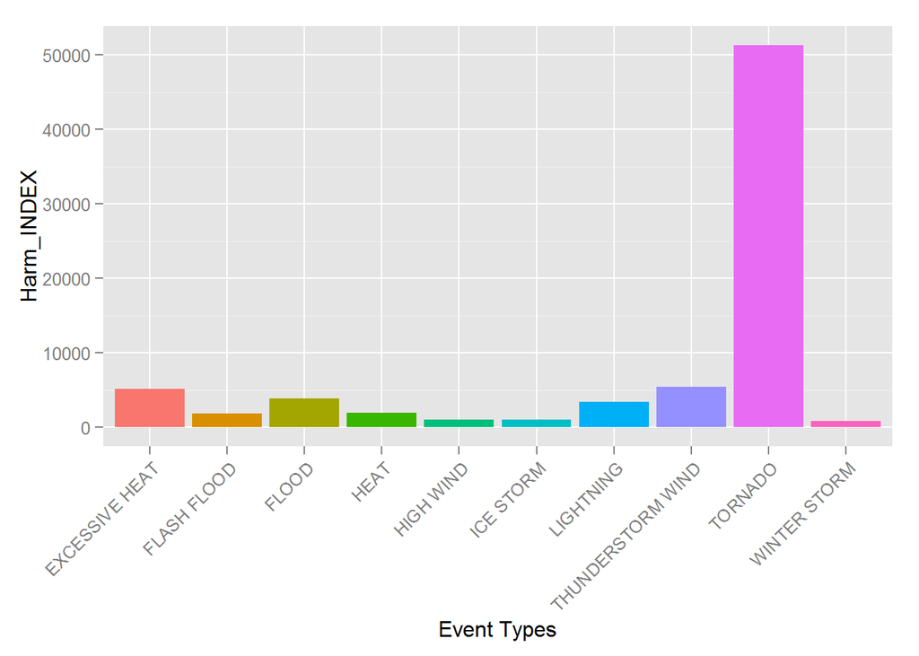

```r
library(plyr)
library(ggplot2)

top10.harm.EV<-head(arrange(data.fatal, Harm_INDEX, decreasing=TRUE),10)

p<-ggplot(top10.harm.EV,aes(x=cate,y=Harm_INDEX,fill=cate))
p<-p+labs(x="Event Types") + theme(legend.position="none")
p<-p+theme(axis.text.x=element_text(angle=45, hjust = 1))
p<-p+geom_bar(stat="identity")

print(p)
```

```r
top10.harm.EV
```

```
##                 cate FATALITIES INJURIES Harm_INDEX   DMG_INDEX
## 1            TORNADO       5633    91364    51315.0  57.3568930
## 2  THUNDERSTORM WIND        705     9412     5411.0  12.1307688
## 3     EXCESSIVE HEAT       1903     6525     5165.5   0.5001557
## 4              FLOOD        483     6794     3880.0 160.8725596
## 5          LIGHTNING        817     5231     3432.5   0.9457564
## 6               HEAT        937     2100     1987.0   0.4032585
## 7        FLASH FLOOD        999     1785     1891.5  17.8955448
## 8          ICE STORM         89     1975     1076.5   8.9670413
## 9          HIGH WIND        283     1440     1003.0   6.5577428
## 10      WINTER STORM        216     1338      885.0   6.7164412
```

#### Across the United States, which types of events have the greatest economic consequences?

```r
m.dmg.EV<-data.fatal[data.fatal$DMG_INDEX==max(data.fatal$DMG_INDEX),]
```

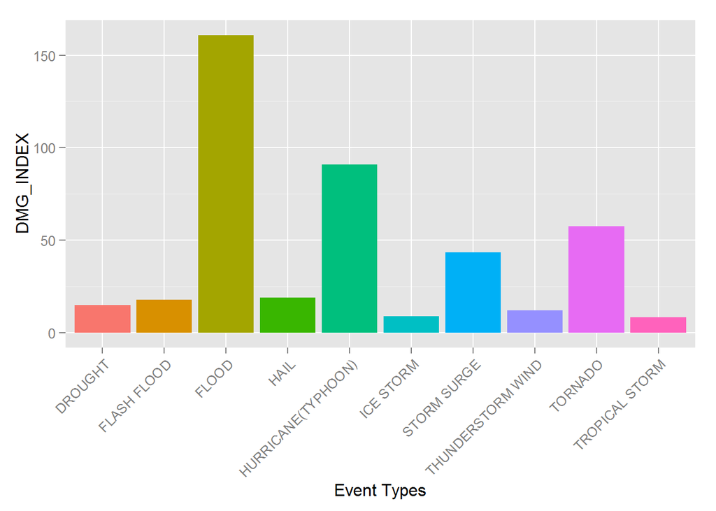

```r
top10.dmg.EV<-head(arrange(data.fatal, DMG_INDEX, decreasing=TRUE),10)

p<-ggplot(top10.dmg.EV,aes(x=cate,y=DMG_INDEX,fill=cate))
p<-p+labs(x="Event Types") + theme(legend.position="none")
p<-p+theme(axis.text.x=element_text(angle=45, hjust = 1))
p<-p+geom_bar(stat="identity")

print(p)
```

```r
top10.dmg.EV
```

```
##                  cate FATALITIES INJURIES Harm_INDEX  DMG_INDEX
## 1               FLOOD        483     6794     3880.0 160.872560
## 2  HURRICANE(TYPHOON)        135     1333      801.5  90.872528
## 3             TORNADO       5633    91364    51315.0  57.356893
## 4         STORM SURGE         13       38       32.0  43.323541
## 5                HAIL         15     1371      700.5  18.779876
## 6         FLASH FLOOD        999     1785     1891.5  17.895545
## 7             DROUGHT          0        4        2.0  15.018672
## 8   THUNDERSTORM WIND        705     9412     5411.0  12.130769
## 9           ICE STORM         89     1975     1076.5   8.967041
## 10     TROPICAL STORM         58      340      228.0   8.382237
```